### 1. Expected value of $S$

The expected value of $S$ in a binomial distribution is $E(S) = N \cdot p$, where: - $N = 25$ (the sample size) - $p$ is the proportion of Democrats in the population

```r
N <- 25
p <- 0.5
E_S <- N * p
E_S
```

```
## [1] 12.5
```

### 2. Standard error of $S$

The standard error (SE) of $S$ in a binomial distribution is $SE(S) = \sqrt{N \cdot p \cdot (1 - p)}$.

```r
SE_S <- sqrt(N * p * (1 - p))
SE_S
```

```
## [1] 2.5
```

### 3. Expected value of $\bar{X}$

$\bar{X}$ is the sample average, which is equivalent to $S / N$. The expected value of $\bar{X}$ is just $p$ because the sample average should estimate the proportion of Democrats.

```r
E_X_bar <- p
E_X_bar
```

```
## [1] 0.5
```

### 4. Standard error of $\bar{X}$

The standard error of $\bar{X}$ is $SE(\bar{X}) = \frac{\sqrt{p \cdot (1 - p)}}{\sqrt{N}}$.

```r
SE_X_bar <- sqrt(p * (1 - p)) / sqrt(N)
SE_X_bar
```

```
## [1] 0.1
```

### 5. Plotting the standard error for different values of $p$

To plot the standard error $SE$ for different values of $p$, we can use a sequence of $p$ values ranging from 0 to 1 and plot $SE$ versus $p$.

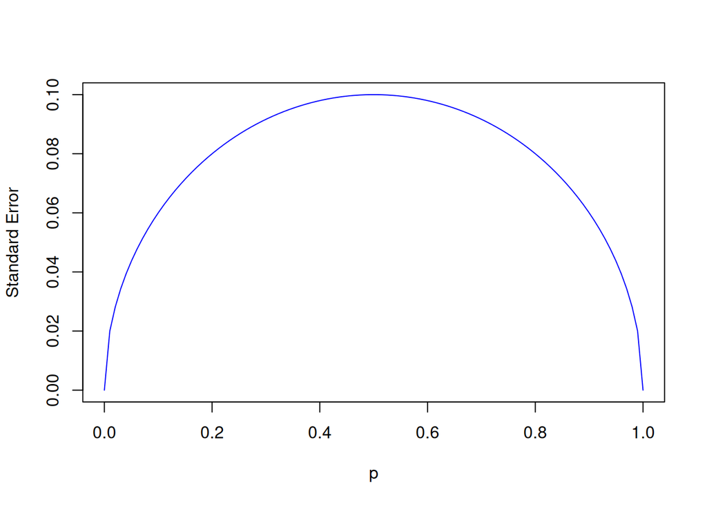

```r
p_vals <- seq(0, 1, length = 100)
se_vals <- sqrt(p_vals * (1 - p_vals)) / sqrt(N)
plot(p_vals, se_vals, type = "l", col = "blue", xlab = "p", ylab = "Standard Error")
```

### 6. Plotting for different values of $N$

To extend the previous code to plot for $N = 25$, $N = 100$, and $N = 1000$, you can use a loop.

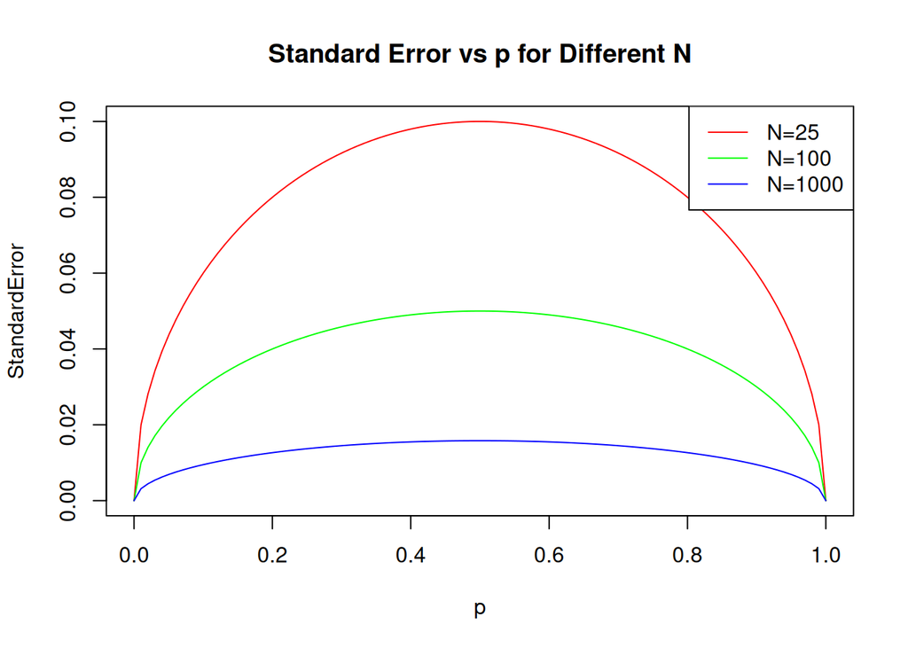

```r
# Define values for p
p_vals <- seq(0, 1, length = 100)

# Define the values for N and their corresponding colors
N_vals <- c(25, 100, 1000)
colors <- c("red", "green", "blue")

# Create the initial plot with the first set of N = 25
N <- N_vals[1]
se_vals <- sqrt(p_vals * (1 - p_vals)) / sqrt(N)
plot(p_vals, se_vals, type = "l", col = colors[1], xlab = "p", ylab ="StandardError", ylim = c(0, max(se_vals)), main = "Standard Error vs p for Different N")

# Now, add the lines for N = 100 and N = 1000
for (i in 2:length(N_vals)) {
    N <- N_vals[i]
    se_vals <- sqrt(p_vals * (1 - p_vals)) / sqrt(N)
    lines(p_vals, se_vals, col = colors[i])
}

# Add a legend to the plot
legend("topright", legend = c("N=25", "N=100", "N=1000"), col = colors, lty = 1)
```

### 7. Expected value of $d$

The difference $d$ is $d = \bar{X} - (1 - \bar{X})$, which simplifies to $d = 2\bar{X} - 1$. The expected value of $d$ is $E(d) = 2p - 1$.

```r
E_d <- 2 * p - 1
E_d
```

```
## [1] 0
```

### 8. Standard error of $d$

Since $d = 2\bar{X} - 1$, the standard error of $d$ is $SE(d) = 2 \times SE(\bar{X})$.

```r
SE_d <- 2 * SE_X_bar
SE_d
```

```
## [1] 0.2
```

### 9. Standard error with $p = 0.45$

If $p = 0.45$, we can compute the standard error for $d$ with $N = 25$.

```r
p <- 0.45
N <- 25
SE_X_bar <- sqrt(p * (1 - p)) / sqrt(N)
SE_d <- 2 * SE_X_bar
SE_d
```

```
## [1] 0.1989975
```

### 10. Strategy for using $N = 25$

Given the standard error computed above, you can evaluate whether the standard error is large relative to the difference and decide if the sample size is sufficient.